# Assign5

1) Load the dataset and display a scatter plot with all the data instances. Column 1 needs to be plotted on the X-axis and Column 2 on the Y-axis. Color code the points based on their class label. That is, instances of the same class should be displayed with the same color. Another color needs to be used for instances of the second class. This plot will show you the distribution of the two classes. Split the dataset into training and testing (70-30 split). To do this, when you call the train_test_split function make sure you specify the random_state parameter like this, random_state=0. This is to ensure that we all get the same train and test splits.

[output not shown]

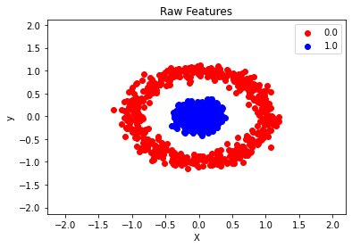

```python
import numpy as np
import matplotlib.pyplot as plt
from matplotlib.colors import ListedColormap
import pandas as pd

#Load the dataset
dataset = pd.read_csv('data.csv')
X = dataset.iloc[:,:-1].values
y = dataset.iloc[:,2].values

#plot raw data
X_set, y_set = X, y
X1, X2 = np.meshgrid(np.arange(start = X_set[:, 0].min() - 1, stop = X_set[:, 0].max() + 1, step = 0.01),
                     np.arange(start = X_set[:, 1].min() - 1, stop = X_set[:, 1].max() + 1, step = 0.01))
plt.xlim(X1.min(), X1.max())
plt.ylim(X2.min(), X2.max())
for i, j in enumerate(np.unique(y_set)):
    plt.scatter(X_set[y_set == j, 0], X_set[y_set == j, 1],
                c = ListedColormap(('red', 'blue'))(i), label = j)
plt.title('Raw Features')
plt.xlabel('X')
plt.ylabel('y')
plt.legend()
plt.show()

#Split the data into Training Set and Test Set
from sklearn.model_selection import train_test_split
X_train, X_test, y_train, y_test = train_test_split(X,y,test_size=0.3,random_state=0)
```

2) Fit a logistic regression model. What is the model accuracy on the test set?

```python
#Normalizing the features
from sklearn.preprocessing import StandardScaler
sc_X = StandardScaler()
X_train = sc_X.fit_transform(X_train)
X_test = sc_X.transform(X_test)


#Fit Logistic Regression to Training Set
from sklearn.linear_model import LogisticRegression
LRObj = LogisticRegression(random_state=0)
LRObj.fit(X_train, y_train)

#Model Accuracy
print(LRObj.score(X_test,y_test))
```

```
0.33
```

3) Perform PCA on the dataset and retain 2 principal components. Visualize this 2 dimensional data with a scatter plot like before. (Same color for class labels as above).

[output not shown]

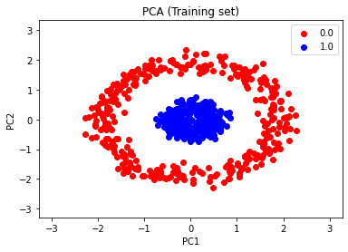

```python
from sklearn.decomposition import PCA
pcaObj = PCA(n_components=2)
X_train_pca = pcaObj.fit_transform(X_train)
X_test_pca  = pcaObj.transform(X_test)
#components_variance_pca = pcaObj.explained_variance_ratio_
#print(components_variance_pca)

#plot data
X_set, y_set = X_train_pca, y_train
X1, X2 = np.meshgrid(np.arange(start = X_set[:, 0].min() - 1, stop = X_set[:, 0].max() + 1, step = 0.01),
                     np.arange(start = X_set[:, 1].min() - 1, stop = X_set[:, 1].max() + 1, step = 0.01))

plt.xlim(X1.min(), X1.max())
plt.ylim(X2.min(), X2.max())
for i, j in enumerate(np.unique(y_set)):
    plt.scatter(X_set[y_set == j, 0], X_set[y_set == j, 1],
                c = ListedColormap(('red', 'blue'))(i), label = j)
plt.title('PCA (Training set)')
plt.xlabel('PC1')
plt.ylabel('PC2')
plt.legend()
plt.show()
```

4) Fit a logistic regression model on this dataset. What is the model accuracy on the test set?

```python
LR_PCA_Obj = LogisticRegression(random_state=0)
LR_PCA_Obj.fit(X_train_pca, y_train)

#Model Accuracy
print(LR_PCA_Obj.score(X_test_pca,y_test))
```

```
0.33
```

5) Now perform PCA and retain only one principal component and visualize the data like before. This time your plot should be a horizontal line since you have just one dimension.

[output not shown]

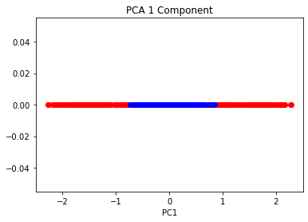

```python
pcaObj1 = PCA(n_components=1)
X_train_pca1 = pcaObj1.fit_transform(X_train)
X_test_pca1  = pcaObj1.transform(X_test)
#components_variance_pca1 = pcaObj1.explained_variance_ratio_
#print(components_variance_pca1)

#plot data
X_set, y_set = X_train_pca1, y_train
X1=np.arange(start = X_set[:, 0].min() - 1, stop = X_set[:, 0].max() + 1, step = 0.01)
y_zeros = np.zeros_like(X_train_pca1)

for i, j in enumerate(np.unique(y_set)):
    plt.scatter(X_set[y_set == j, 0], y_zeros[y_set == j, 0],
                c = ListedColormap(('red', 'blue'))(i), label = j)

plt.title('PCA 1 Component')
plt.xlabel('PC1')
plt.show()
```

6) Fit a logistic regression model on this dataset. What is the model accuracy on the test set?

```python
LR_PCA1_Obj = LogisticRegression(random_state=0)
LR_PCA1_Obj.fit(X_train_pca1, y_train)

#Model Accuracy
print(LR_PCA1_Obj.score(X_test_pca1,y_test))
```

```
0.3433333333333333
```

7) Perform LDA. Your dataset should have just one dimension. Visualize this data like before.

[output not shown]

```
[1.]
```

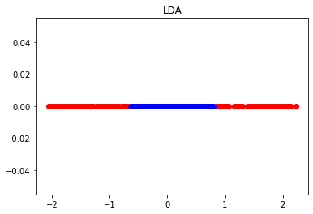

```python
#Applying LDA
from sklearn.discriminant_analysis import LinearDiscriminantAnalysis as LDA
ldaObj = LDA(n_components=1)
X_train_lda = ldaObj.fit_transform(X_train,y_train)
X_test_lda = ldaObj.transform(X_test)
components_variance = ldaObj.explained_variance_ratio_
print(components_variance)

#plot data
X_set, y_set = X_train_lda, y_train
X1= np.meshgrid(np.arange(start = X_set[:, 0].min() - 1, stop = X_set[:, 0].max() + 1, step = 0.001))
y_zeros = np.zeros_like(X_train_pca1)

for i, j in enumerate(np.unique(y_set)):
    plt.scatter(X_set[y_set == j, 0], y_zeros[y_set == j, 0],
                c = ListedColormap(('red', 'blue'))(i), label = j)
plt.title('LDA')
plt.show()
```

8) Fit a logistic regression model on this dataset. What is the model accuracy on the test set?

```python
LR_LDA_Obj = LogisticRegression(random_state=0)
LR_LDA_Obj.fit(X_train_lda, y_train)

#Model Accuracy
print(LR_LDA_Obj.score(X_test_lda,y_test))
```

```
0.33
```

9) Perform Kernel PCA and retain two components. Visualize this data like before.

[output not shown]

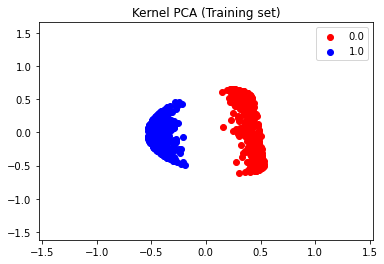

```python
#kernel PCA
from sklearn.decomposition import KernelPCA
kernelPCAObj = KernelPCA(n_components=2, kernel='rbf')
X_train_kpca = kernelPCAObj.fit_transform(X_train)
X_test_kpca = kernelPCAObj.transform(X_test)

#plot data
X_set, y_set = X_train_kpca, y_train
X1, X2 = np.meshgrid(np.arange(start = X_set[:, 0].min() - 1, stop = X_set[:, 0].max() + 1, step = 0.001),
                     np.arange(start = X_set[:, 1].min() - 1, stop = X_set[:, 1].max() + 1, step = 0.001))
plt.xlim(X1.min(), X1.max())
plt.ylim(X2.min(), X2.max())
for i, j in enumerate(np.unique(y_set)):
    plt.scatter(X_set[y_set == j, 0], X_set[y_set == j, 1],
                c = ListedColormap(('red', 'blue'))(i), label = j)
plt.title('Kernel PCA (Training set)')
plt.legend()
plt.show()
```

10) Fit a logistic regression model on this dataset. What is the model accuracy on the test set

```python
kPCAObj = LogisticRegression(random_state=0)
kPCAObj.fit(X_train_kpca, y_train)

#Model Accuracy
print(kPCAObj.score(X_test_kpca,y_test))
```

```
1.0
```